# Data Exploration

What kind of information holds the training set? For what does each column stend for? Are there any false observations, anomalies?

From the names of the columns and the first few rows, we get, that the training set consist of historical purchases of different product from different customers:

- the id of the order (order_id)
- the id of the customer (contact_id)
- the id of the product (product_id)
- date of purchase (purchase_date)
- quantity of product in order (quantity)
- the amount paid (sales_amount)

```r
library(dplyr)
library(ggplot2)
library(gridExtra)
library(lubridate)

source("R/utils.R")

purchases <- loadPurchases()
summary(purchases)
```

```
##    order_id          contact_id        purchase_date
##  Length:544387      Length:544387      Min.   :2012-01-01
##  Class :character   Class :character   1st Qu.:2012-06-16
##  Mode  :character   Mode  :character   Median :2012-11-22
##                                        Mean   :2012-12-06
##                                        3rd Qu.:2013-05-28
##                                        Max.   :2013-12-31
##   product_id           quantity        sales_amount
##  Length:544387      Min.   : -1.000   Min.   :  -36.95
##  Class :character   1st Qu.:  1.000   1st Qu.:   21.95
##  Mode  :character   Median :  1.000   Median :   39.90
##                     Mean   :  1.212   Mean   :   66.30
##                     3rd Qu.:  1.000   3rd Qu.:   76.96
##                     Max.   :260.000   Max.   :10997.50
```

```r
head(purchases, 20)
```

```
##    order_id contact_id purchase_date product_id quantity sales_amount
## 1   4852169   17846335    2012-01-01    3308032        1        18.71
## 2   3570597   18759585    2012-01-01   37220513        2        83.50
## 3  32096674    5025194    2012-01-01   10259603        1        19.95
## 4   2904402   29624779    2012-01-01    3308032        1        18.71
## 5  38369470   42287117    2012-01-01    3308032        1        18.71
## 6  10514626   34476502    2012-01-01   21913642        2        39.90
## 7  36513528    5025194    2012-01-01   30518406        1        45.56
## 8   6595294   14603912    2012-01-01   16308207        4       159.80
## 9  18187529   10412066    2012-01-01   11543327        1       239.95
## 10 37889477   35117040    2012-01-01   21103908        1        37.95
## 11  8332160   38480502    2012-01-01   48230008        1        45.85
## 12 33518087     379181    2012-01-01   20397699        1        21.95
## 13 33518087     379181    2012-01-01   44082225        1        21.95
## 14 14636043   12593742    2012-01-01   33933022        1       138.88
## 15 31422945     896883    2012-01-01   22471139        1        64.95
## 16  2456213   48131541    2012-01-01    7489558        1        59.99
## 17  2456213   48131541    2012-01-01    9399633        1        11.95
## 18 29653733   14484783    2012-01-01   24761921        2        19.90
## 19 14378821   22313976    2012-01-01   22283117        1         8.95
## 20 31933423   33273808    2012-01-01    3308032        1        18.71
```

Observing the summary, we can see, that the purchases roughly occur in a consistent basis and usually, the customers purchase 1 piece at a time from a product.

- Comment: since the sales_amount represents the amount paid within an order for a product(independently from the quantity), it would be more reasonable to look at the whole amount paid within an order.
- Comment: from the summary, we see, that the minimum of the quantity and the sales_amount is negative. We won’t examing this case or other possibilities of false observations (for example: duplicates, 0 quantity or amount), since it has been already clarified.

### Order frequency

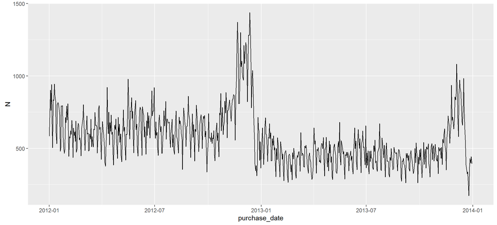

```r
purchases %>%
  dplyr::select(order_id, purchase_date) %>%
  group_by(purchase_date) %>%
  summarise(N = length(unique(order_id))) %>%
  ggplot() +
  geom_line(aes(purchase_date, N), stat = "identity")
```

### Quantities of products within an order (with at least 2 hits)

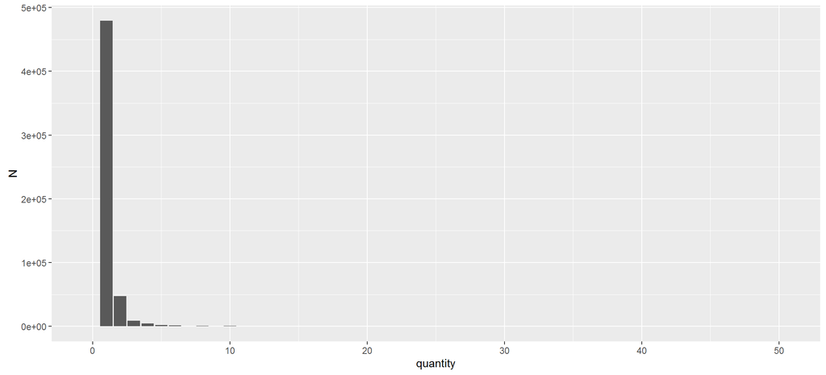

```r
purchases %>%
  dplyr::select(quantity) %>%
  group_by(quantity) %>%
  summarise(N = n()) %>%
  filter(N > 1) %>%
  ggplot() +
  geom_bar(aes(quantity, N), stat = "identity")
```

### Sales amount of orders categorized

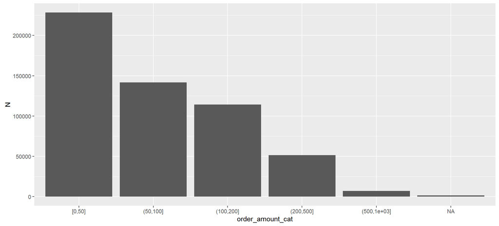

```r
purchases %>%
  dplyr::select(order_id, sales_amount) %>%
  group_by(order_id) %>%
  mutate(
    order_amount = sum(sales_amount),
    order_amount_cat = order_amount %>%
      cut(
        c(0, 50, 100, 200, 500, 1000),
        include.lowest = T
      )
  ) %>%
  group_by(order_amount_cat) %>%
  summarise(N = n()) %>%
  ggplot() +
  geom_bar(aes(order_amount_cat,  N), stat = "identity")
```

### (Weighted) Differences in sales amount of products/piece

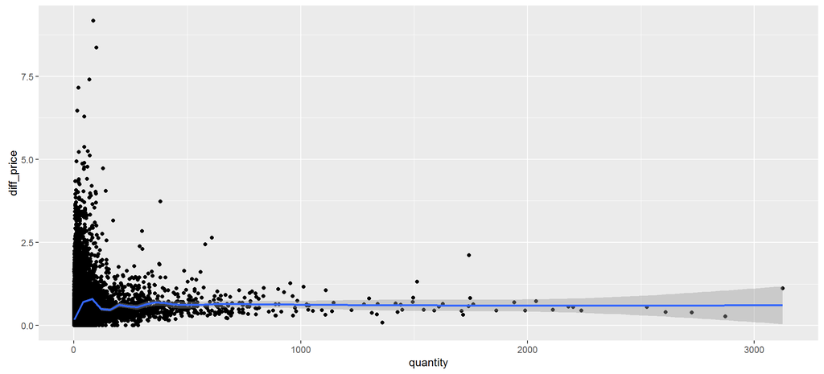

```r
purchases %>%
  dplyr::select(product_id, quantity, sales_amount) %>%
  filter(quantity > 0 & sales_amount > 0) %>%
  mutate(product_price = sales_amount / quantity) %>%
  group_by(product_id) %>%
  summarise(
    quantity = sum(quantity),
    avg_price = mean(product_price),
    diff_price = (max(product_price) - min(product_price)) / avg_price
  ) %>%
  ggplot(aes(quantity, diff_price)) +
  geom_jitter() +
  geom_smooth()
```

## Overview of the frequency and amount of purchases (without taking in account the customer or product)

Since we have seen, that there is a trend in the frequency of purchases, it is likely, that there will be also a trend in the amount Since we don’t consider the customer or product in this overview, we won’t need the related columns.

```r
sales_raw <- purchases %>%
  dplyr::select(order_id, purchase_date, sales_amount) %>%
  group_by(order_id, purchase_date) %>%
  summarise(sales_amount = sum(sales_amount)) %>%
  ungroup()
```

Calculate the amount of purchases /year day, /weekday, /month, /year

```r
sales <- sales_raw %>%
  dplyr::select(sales_amount, purchase_date) %>%
  group_by(purchase_date) %>%
  summarise(total_sales = sum(sales_amount)) %>%
  ungroup() %>%
  mutate(
    month = months(purchase_date),
    month = factor(
      month,
      levels = c(
        "január",
        "február",
        "március",
        "április",
        "május",
        "június",
        "július",
        "augusztus",
        "szeptember",
        "október",
        "november",
        "december"
      )
    ),
    weekday = weekdays(purchase_date),
    weekday = factor(
      weekday,
      levels = c(
        "hétfő",
        "kedd",
        "szerda",
        "csütörtök",
        "péntek",
        "szombat",
        "vasárnap"
      )
    ),
    week = isoweek(purchase_date),
    year = factor(year(purchase_date)),
    day_num = yday(purchase_date)
  )
```

### Daily amount of purchases compared by year

We can see an overall decrease in 2013, with having the same trend within a year.

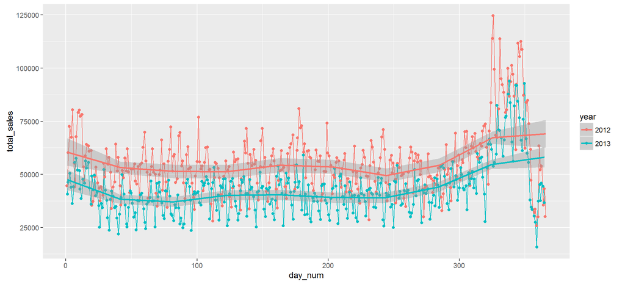

```r
ggplot(data = sales, aes(
  x = day_num,
  y = total_sales,
  group = year,
  color = year
)) +
  geom_line() +
  geom_jitter() +
  geom_smooth(n = 10, span = 0.5)
```

### Sales amount per days of week, weeks of year and months of year

- Days of week: We can see, that customers spent more in the middle of the work week and spent the less on Saturdays
- Weeks of year/months of year: customers spent the most before christmas(week 47-50 / end of november, beginning of december)

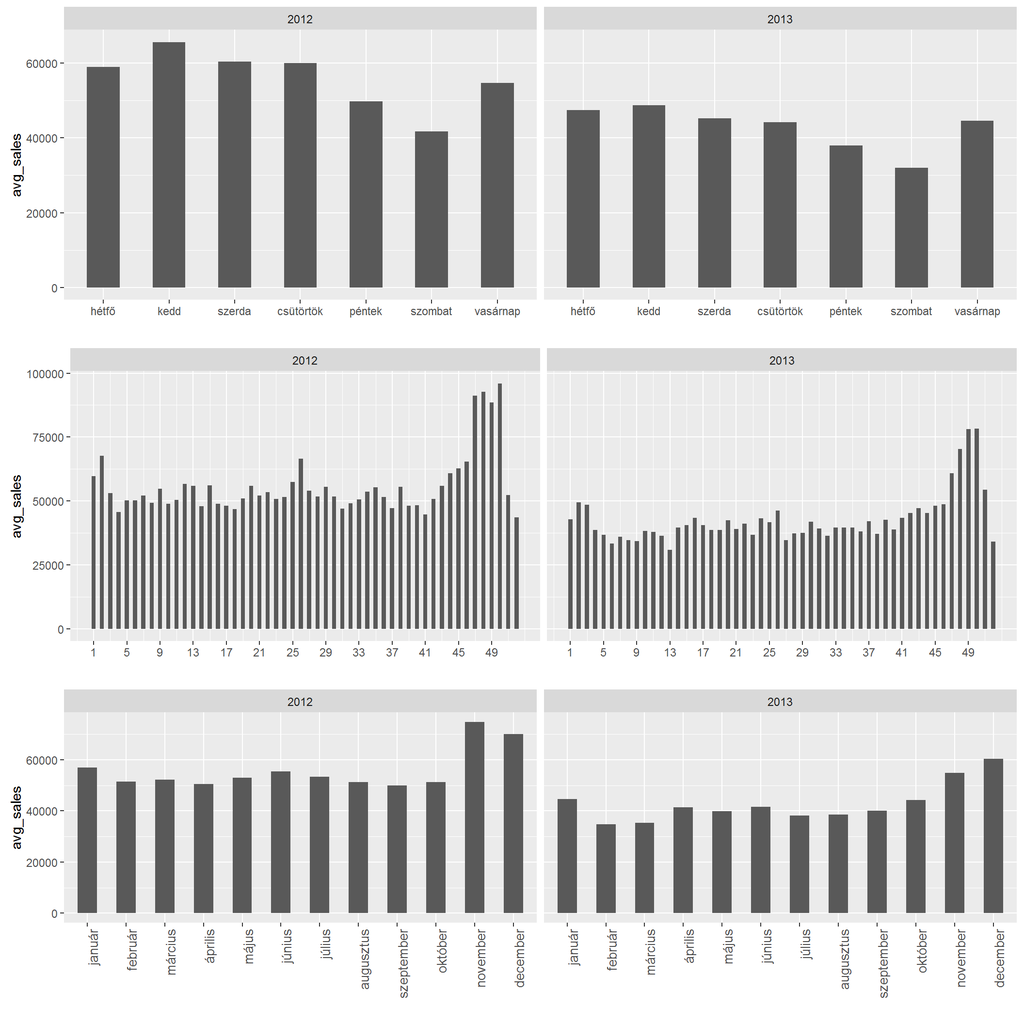

```r
sales_weekdays <- sales %>%
  group_by(year, weekday) %>%
  summarise(avg_sales = weighted.mean(total_sales)) %>%
  rename(grouping = weekday)

sales_weeks <- sales %>%
  group_by(year, week) %>%
  summarise(avg_sales = weighted.mean(total_sales)) %>%
  rename(grouping = week)

sales_months <- sales %>%
  group_by(year, month) %>%
  summarise(avg_sales = weighted.mean(total_sales)) %>%
  rename(grouping = month)

sales_weekdays_plot <-
  ggplot(sales_weekdays, aes(x = grouping, y = avg_sales)) +
  geom_bar(stat = "identity", width = 0.5) + xlab("")  + facet_grid(. ~ year)
sales_weeks_plot <- sales_weekdays_plot %+% sales_weeks +
  scale_x_continuous(breaks = seq(min(sales_weeks$grouping), max(sales_weeks$grouping), by = 4))
sales_months_plot <- sales_weekdays_plot %+% sales_months +
  theme(axis.text.x = element_text(angle = 90, hjust = 1, size = 10))

grid.arrange(sales_weekdays_plot,
             sales_weeks_plot,
             sales_months_plot,
             ncol = 1)
```